# RD modelling - simulations

Doranne Thomassen

03/22/2021

# Single trial

## Binary treatment variable + binary covariate

```r
set.seed(456)
n_arm <- 500
treat <- c(rep(0,n_arm), rep(1,n_arm))
cat("", file = "modelstats_bin.html", append = FALSE)

beta_xlim = c(0,0.6)
beta_ylim = c(0,20)

#beta1=beta2=0.3, increase alpha
#alpha = 0.2
x <- c(rbinom(n=n_arm, size=1, prob = 0.5), rbinom(n=n_arm, size=1, prob = 0.5))
true.beta <- 0.3
true.p <- 0.2+true.beta*treat+0.3*x
xpred <- c(0,1)
TEfun <- function(x){
  return(true.beta)
}

cure <- rbinom(n=length(treat), size=1, prob = true.p)
trial.dat <- data.frame(cure, treat, x)


plots <- run.sim(true.beta=true.beta,
        trial.dat = trial.dat,
        filename="2x_bin_p=0.2+0.3x+0.3x",
        title=expression(paste(x[i*1], " binary, ", x[i*2], " binary, ", p[i],"=0.2+0.3",x[i*1],"+0.3",x[i*2],".")),
        true.p = true.p,
        true.TE.fun=TEfun,
        xpred = xpred)

beta.plot <- plots$beta.frame
plots$kable_modstats
```

1. Proposed model
3. Logistic model + transform
2. Model by Warn et al.

MLE binomial GLM id-link

MLE binomial GLM logit-link

OLS estimate

Brier.mean

0.2039

0.2039

0.2039

0.2039

0.2039

0.2039

Brier.median

0.2039

0.2039

0.2039

0.2039

0.2039

0.2039

RMSE.p.mean

0.0118

0.0110

0.0119

0.0116

0.0116

0.0116

RMSE.p.median

0.0117

0.0111

0.0121

0.0116

0.0116

0.0116

MAE.p.mean

0.0097

0.0085

0.0101

0.0088

0.0088

0.0088

MAE.p.median

0.0092

0.0081

0.0101

0.0088

0.0088

0.0088

IC

1194.9127

1195.2301

1194.9157

1195.0631

1195.0598

NA

Rhat_Conv

1.0081

1.0045

1.0005

-1.0000

-1.0000

-1.0000

RunTimes

13.5459

22.6216

14.8531

0.0061

0.0033

0.0013

ESSp0

280.0000

310.0000

2000.0000

0.0000

0.0000

0.0000

ESSp1

280.0000

520.0000

2000.0000

0.0000

0.0000

0.0000

```r
rm(cure, trial.dat, true.beta, true.p, x, xpred)

#alpha = 0.3
x <- c(rbinom(n=n_arm, size=1, prob = 0.5), rbinom(n=n_arm, size=1, prob = 0.5))
true.beta <- 0.3
true.p <- 0.3+true.beta*treat+0.3*x
xpred <- c(0,1)
TEfun <- function(x){
  return(true.beta)
}

cure <- rbinom(n=length(treat), size=1, prob = true.p)
trial.dat <- data.frame(cure, treat, x)


plots <- run.sim(true.beta=true.beta,
        trial.dat = trial.dat,
        filename="2x_bin_p=0.3+0.3x+0.3x",
        title=expression(paste(x[i*1], " binary, ", x[i*2], " binary, ", p[i],"=0.3+0.3",x[i*1],"+0.3",x[i*2],".")),
        true.p = true.p,
        true.TE.fun=TEfun,
        xpred = xpred,
        beta_xlim = c(0,0.6),
        beta_ylim = c(0,20))

beta.plot <- rbind(beta.plot, plots$beta.frame)
plots$kable_modstats
```

1. Proposed model
3. Logistic model + transform
2. Model by Warn et al.

MLE binomial GLM id-link

MLE binomial GLM logit-link

OLS estimate

Brier.mean

0.1969

0.1980

0.1969

0.1969

0.1980

0.1968

Brier.median

0.1969

0.1980

0.1968

0.1969

0.1980

0.1968

RMSE.p.mean

0.0158

0.0273

0.0148

0.0157

0.0270

0.0164

RMSE.p.median

0.0160

0.0272

0.0147

0.0157

0.0270

0.0164

MAE.p.mean

0.0132

0.0223

0.0125

0.0124

0.0220

0.0147

MAE.p.median

0.0130

0.0220

0.0122

0.0124

0.0220

0.0147

IC

1151.9971

1159.3875

1152.0723

1152.2187

1159.1747

NA

Rhat_Conv

1.0006

1.0041

1.0016

-1.0000

-1.0000

-1.0000

RunTimes

13.1990

16.1556

13.6229

0.0021

0.0019

0.0008

ESSp0

2000.0000

900.0000

1700.0000

0.0000

0.0000

0.0000

ESSp1

2000.0000

550.0000

1300.0000

0.0000

0.0000

0.0000

```r
rm(cure, trial.dat, true.beta, true.p, x, xpred)


#alpha = 0.39
x <- c(rbinom(n=n_arm, size=1, prob = 0.5), rbinom(n=n_arm, size=1, prob = 0.5))
true.beta <- 0.3
true.p <- 0.39+true.beta*treat+0.3*x
xpred <- c(0,1)
TEfun <- function(x){
  return(true.beta)
}

cure <- rbinom(n=length(treat), size=1, prob = true.p)
trial.dat <- data.frame(cure, treat, x)


plots <- run.sim(true.beta=true.beta,
        trial.dat = trial.dat,
        filename="2x_bin_p=0.39+0.3x+0.3x",
        title=expression(paste(x[i*1], " binary, ", x[i*2], " binary, ", p[i],"=0.39+0.3",x[i*1],"+0.3",x[i*2],".")),
        true.p = true.p,
        true.TE.fun=TEfun,
        xpred = xpred,
        beta_xlim = c(0,0.6),
        beta_ylim = c(0,20))

beta.plot <- rbind(beta.plot, plots$beta.frame)
plots$kable_modstats
```

1. Proposed model
3. Logistic model + transform
2. Model by Warn et al.

MLE binomial GLM id-link

MLE binomial GLM logit-link

OLS estimate

Brier.mean

0.1699

0.1714

0.1699

0.1698

0.1714

0.1698

Brier.median

0.1699

0.1714

0.1699

0.1698

0.1714

0.1698

RMSE.p.mean

0.0143

0.0495

0.0149

0.0140

0.0495

0.0124

RMSE.p.median

0.0143

0.0498

0.0146

0.0140

0.0495

0.0124

MAE.p.mean

0.0118

0.0479

0.0125

0.0119

0.0480

0.0103

MAE.p.median

0.0117

0.0482

0.0122

0.0119

0.0480

0.0103

IC

1003.6280

1019.5694

1003.4862

1003.6242

1018.8419

NA

Rhat_Conv

1.0005

1.0007

1.0018

-1.0000

-1.0000

-1.0000

RunTimes

13.7628

15.4465

12.8887

0.0020

0.0021

0.0008

ESSp0

2000.0000

2000.0000

2000.0000

0.0000

0.0000

0.0000

ESSp1

2000.0000

670.0000

2000.0000

0.0000

0.0000

0.0000

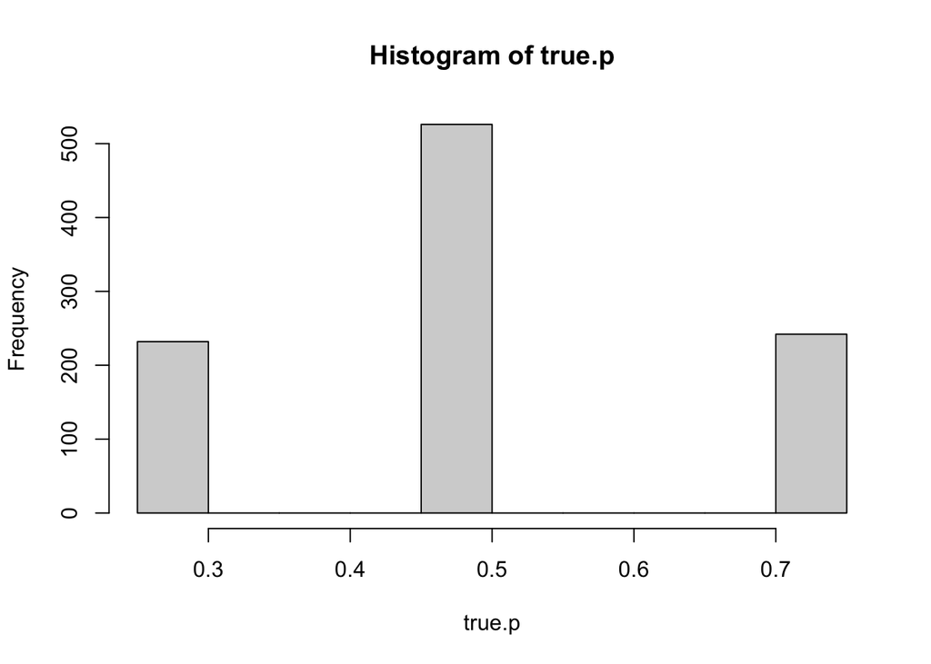

```r
rm(cure, trial.dat, true.beta, true.p, x, xpred)


#alpha=-1
x <- c(rbinom(n=n_arm, size=1, prob = 0.5), rbinom(n=n_arm, size=1, prob = 0.5))
true.beta <- NA
true.p <- expit(-1+1*treat+x)
hist(true.p)
```

```r
xpred <- c(0,1)
TEfun <- function(x){
  TE <- expit(-1+1+x)-expit(-1+0+x)
  return(TE)
}

cure <- rbinom(n=length(treat), size=1, prob = true.p)
trial.dat <- data.frame(cure, treat, x)

plots <- run.sim(true.beta=true.beta,
        trial.dat = trial.dat,
        filename="2x_bin_p=expit(-1+x+x)",
        title=expression(paste(x[i*1], " binary, ", x[i*2], " binary, ", p[i],"=expit(-1+",x[i*1],"+",x[i*2],")")),
        true.p = true.p,
        true.TE.fun=TEfun,
        xpred = xpred,
        beta_xlim = c(0,0.6),
        beta_ylim = c(0,20))

beta.plot <- rbind(beta.plot, plots$beta.frame)
plots$kable_modstats
```

1. Proposed model
3. Logistic model + transform
2. Model by Warn et al.

MLE binomial GLM id-link

MLE binomial GLM logit-link

OLS estimate

Brier.mean

0.2257

0.2256

0.2257

0.2257

0.2256

0.2257

Brier.median

0.2257

0.2256

0.2257

0.2257

0.2256

0.2257

RMSE.p.mean

0.0111

0.0140

0.0119

0.0113

0.0133

0.0133

RMSE.p.median

0.0112

0.0141

0.0119

0.0113

0.0133

0.0133

MAE.p.mean

0.0099

0.0132

0.0109

0.0106

0.0127

0.0127

MAE.p.median

0.0100

0.0134

0.0109

0.0106

0.0127

0.0127

IC

1291.5854

1291.1225

1291.2416

1291.5882

1291.3757

NA

Rhat_Conv

1.0009

1.0036

1.0010

-1.0000

-1.0000

-1.0000

RunTimes

13.6749

17.2605

14.2863

0.0021

0.0023

0.0010

ESSp0

2000.0000

490.0000

610.0000

0.0000

0.0000

0.0000

ESSp1

2000.0000

370.0000

2000.0000

0.0000

0.0000

0.0000

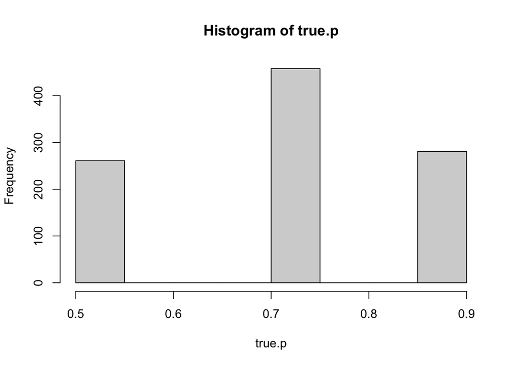

```r
rm(cure, trial.dat, true.beta, true.p, x, xpred)

#alpha=0
x <- c(rbinom(n=n_arm, size=1, prob = 0.5), rbinom(n=n_arm, size=1, prob = 0.5))
true.beta <- NA
true.p <- expit(0+1*treat+x)
hist(true.p)
```

```r
xpred <- c(0,1)
TEfun <- function(x){
  TE <- expit(0+1+x)-expit(0+0+x)
  return(TE)
}

cure <- rbinom(n=length(treat), size=1, prob = true.p)
trial.dat <- data.frame(cure, treat, x)

plots <- run.sim(true.beta=true.beta,
        trial.dat = trial.dat,
        filename="2x_bin_p=expit(0+x+x)",
        title=expression(paste(x[i*1], " binary, ", x[i*2], " binary, ", p[i],"=expit(0+",x[i*1],"+",x[i*2],")")),
        true.p = true.p,
        true.TE.fun=TEfun,
        xpred = xpred,
        beta_xlim = c(0,0.6),
        beta_ylim = c(0,20))

beta.plot <- rbind(beta.plot, plots$beta.frame)
plots$kable_modstats
```

1. Proposed model
3. Logistic model + transform
2. Model by Warn et al.

MLE binomial GLM id-link

MLE binomial GLM logit-link

OLS estimate

Brier.mean

0.1783

0.1780

0.1783

0.1782

0.1780

0.1782

Brier.median

0.1782

0.1781

0.1782

0.1782

0.1780

0.1782

RMSE.p.mean

0.0230

0.0182

0.0228

0.0235

0.0184

0.0265

RMSE.p.median

0.0231

0.0190

0.0231

0.0235

0.0184

0.0265

MAE.p.mean

0.0206

0.0172

0.0207

0.0208

0.0174

0.0211

MAE.p.median

0.0205

0.0180

0.0208

0.0208

0.0174

0.0211

IC

1070.9598

1070.1642

1070.9006

1070.6655

1069.9262

NA

Rhat_Conv

1.0007

1.0029

1.0009

-1.0000

-1.0000

-1.0000

RunTimes

13.3086

15.7047

14.9182

0.0027

0.0024

0.0008

ESSp0

2000.0000

740.0000

2000.0000

0.0000

0.0000

0.0000

ESSp1

2000.0000

1000.0000

2000.0000

0.0000

0.0000

0.0000

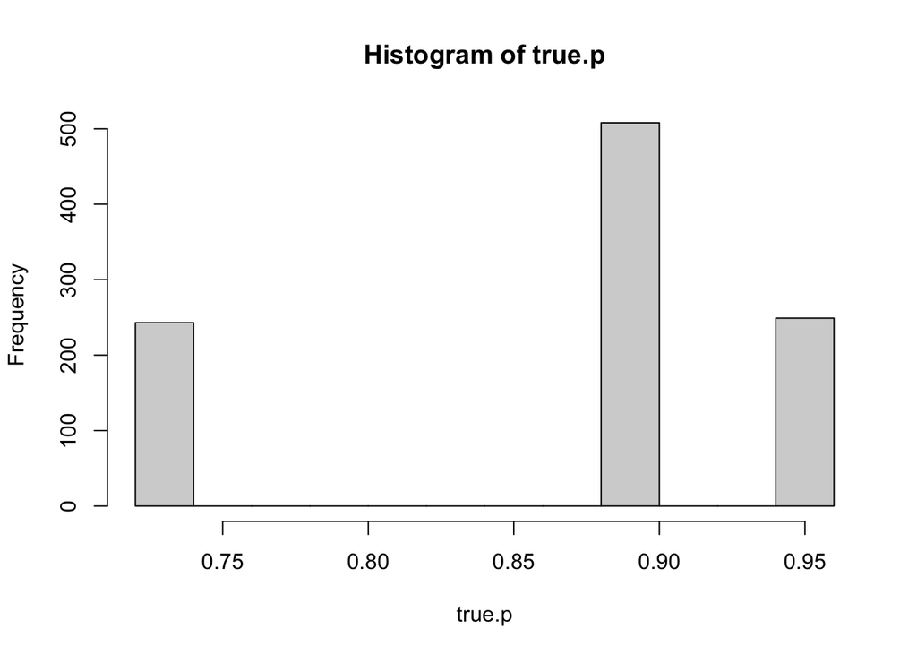

```r
rm(cure, trial.dat, true.beta, true.p, x, xpred)

#alpha=1
x <- c(rbinom(n=n_arm, size=1, prob = 0.5), rbinom(n=n_arm, size=1, prob = 0.5))
true.beta <- NA
true.p <- expit(1+1*treat+x)
hist(true.p)
```

```r
xpred <- c(0,1)
TEfun <- function(x){
  TE <- expit(1+1+x)-expit(1+0+x)
  return(TE)
}

cure <- rbinom(n=length(treat), size=1, prob = true.p)
trial.dat <- data.frame(cure, treat, x)

plots <- run.sim(true.beta=true.beta,
        trial.dat = trial.dat,
        filename="2x_bin_p=expit(1+x+x)",
        title=expression(paste(x[i*1], " binary, ", x[i*2], " binary, ", p[i],"=expit(1+",x[i*1],"+",x[i*2],")")),
        true.p = true.p,
        true.TE.fun=TEfun,
        xpred = xpred,
        beta_xlim = c(0,0.6),
        beta_ylim = c(0,20))

beta.plot <- rbind(beta.plot, plots$beta.frame)
plots$kable_modstats
```

1. Proposed model
3. Logistic model + transform
2. Model by Warn et al.

MLE binomial GLM id-link

MLE binomial GLM logit-link

OLS estimate

Brier.mean

0.1168

0.1155

0.1169

0.1168

0.1155

0.1166

Brier.median

0.1168

0.1154

0.1169

0.1168

0.1155

0.1166

RMSE.p.mean

0.0234

0.0204

0.0234

0.0224

0.0203

0.0271

RMSE.p.median

0.0232

0.0206

0.0235

0.0224

0.0203

0.0271

MAE.p.mean

0.0197

0.0126

0.0197

0.0197

0.0126

0.0260

MAE.p.median

0.0197

0.0125

0.0199

0.0197

0.0126

0.0260

IC

775.9349

768.6421

776.4208

776.2966

767.1591

NA

Rhat_Conv

1.0018

1.0014

1.0007

-1.0000

-1.0000

-1.0000

RunTimes

13.7240

15.4431

13.4086

0.0029

0.0024

0.0008

ESSp0

1100.0000

1100.0000

1000.0000

0.0000

0.0000

0.0000

ESSp1

1100.0000

2000.0000

2000.0000

0.0000

0.0000

0.0000

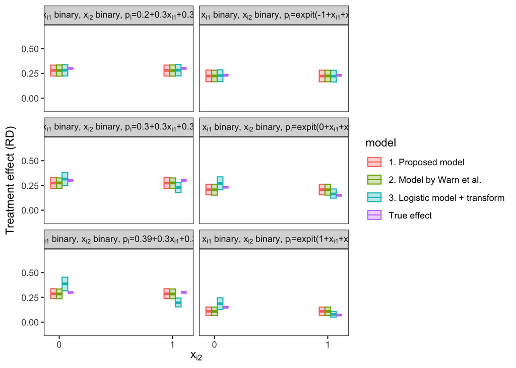

```r
rm(cure, trial.dat, true.beta, true.p, x, xpred)

# Plots
beta.plot$Scenario <- factor(beta.plot$Scenario,
                   levels=c("2x_bin_p=0.2+0.3x+0.3x",
                            "2x_bin_p=0.3+0.3x+0.3x",
                            "2x_bin_p=0.39+0.3x+0.3x",
                            "2x_bin_p=expit(-1+x+x)",
                            "2x_bin_p=expit(0+x+x)",
                            "2x_bin_p=expit(1+x+x)"),
                   labels=c(expression(paste("A. ", x[i*1], " binary, ", x[i*2], " binary, ", p[i],"=0.2+0.3",x[i*1],"+0.3",x[i*2],".")),
                            expression(paste("B. ", x[i*1], " binary, ", x[i*2], " binary, ", p[i],"=0.3+0.3",x[i*1],"+0.3",x[i*2],".")),
                            expression(paste("C. ", x[i*1], " binary, ", x[i*2], " binary, ", p[i],"=0.39+0.3",x[i*1],"+0.3",x[i*2],".")),
                            expression(paste("D. ", x[i*1], " binary, ", x[i*2], " binary, ", p[i],"=expit(-1+",x[i*1],"+",x[i*2],")")),
                            expression(paste("E. ", x[i*1], " binary, ", x[i*2], " binary, ", p[i],"=expit(0+",x[i*1],"+",x[i*2],")")),
                            expression(paste("F. ", x[i*1], " binary, ", x[i*2], " binary, ", p[i],"=expit(1+",x[i*1],"+",x[i*2],")"))
                            ))

plot1<- ggplot()+
      geom_crossbar(data=beta.plot,
                    aes(ymin = TE_low, ymax = TE_upp, fill=model,
                        x=xtilde, y=TE_pred, colour = model),
                    width=0.05, alpha=0.3)+
      xlab(expression(x[i*2]))+
      ylab(expression(paste("Treatment effect (RD)")))+
      theme_bw()+
      theme(panel.grid.minor = element_blank(),
               panel.grid.major = element_blank())+
      #xlim(c(-0.1, 1.1))+
      ylim(c(-0.1,0.7))+
      scale_x_continuous(breaks=c(0, 1))+
      facet_wrap(~Scenario, ncol = 2, dir = "v", labeller = label_parsed)

print(plot1)
```

```r
ggsave(plot = plot1, filename="2x_bin.pdf", height=6, width = 8)
```